# LabWeek7.Rmd

Mason Rossi

2023-05-18

### CLEANING WORKSPACE

```r
rm(list = ls())
```

### Q1 SET WORKING DIRECTORY

```r
setwd("/Users/masonrossi/Desktop/Econ 42/Week 7")
df<-read.csv("https://vincentarelbundock.github.io/Rdatasets/csv/stevedata/gss_wages.csv")
```

### LIBRARIES

```r
library(AER)
library(car)
library(doBy)
library(dplyr)
library(foreign)
library(ggplot2)
library(knitr)
library(sandwich)
library(stargazer)
library(XML)
library(epiDisplay)
library(lmtest)
cse=function(reg) {
    rob=sqrt(diag(vcovHC(reg, type="HC1")))
    return(rob)
    }
opts_chunk$set(echo = TRUE, warning=F, message=F, comment="")
```

### Q2

```r
stargazer(df, type="text")
```

```
==========================================================
Statistic   N       Mean     St. Dev.    Min       Max
----------------------------------------------------------
X         61,697 30,849.000 17,810.530    1      61,697
year      61,697 1,996.074    12.794    1,974     2,018
realrinc  37,887 22,326.360 28,581.790 227.000 480,144.500
age       61,478   46.176     17.561     18        89
occ10     58,136 4,695.774  2,627.724    10       9,997
prestg10  57,511   43.061     12.988     16        80
childs    61,508   1.923      1.764       0         8
----------------------------------------------------------
```

### Q3

```r
df$gender_b <- ifelse(df$gender == "Female", 1, 0)
df$gender_l <- df$gender == "Female"
df$full_time <- ifelse(df$wrkstat == "Full-Time", 1, 0)
```

### Q4

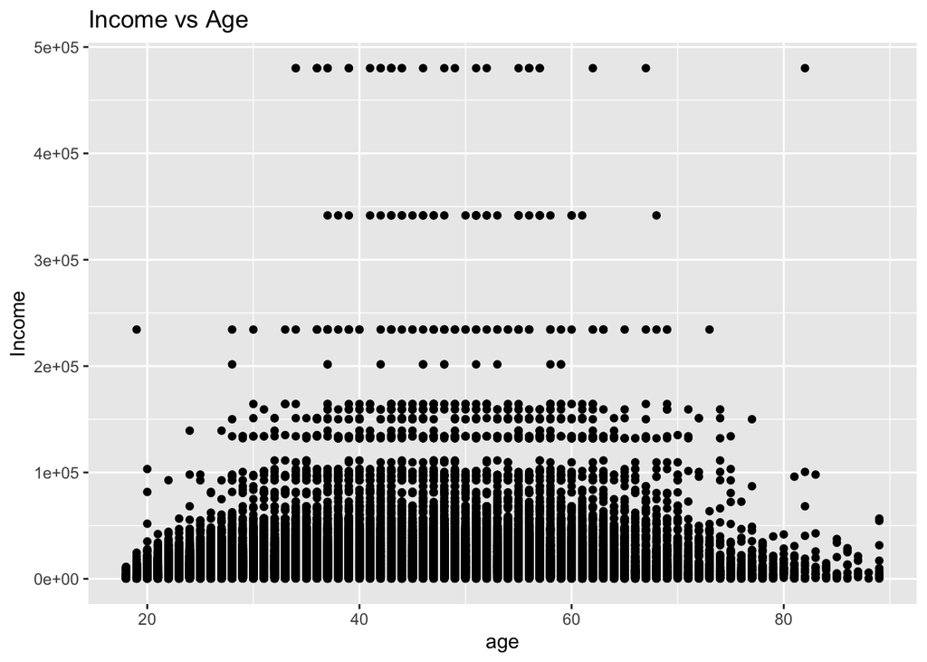

```r
ggplot(df, aes(x = age, y = realrinc)) +
  geom_point() +
  labs(x = "age", y = "Income") +
  ggtitle("Income vs Age")
```

Q5: There is a normal distribution to the data where there exists a nonlinear relationship between age and income.

### Q6

```r
working_age_data <- subset(df, age >= 18 & age <= 64)

model <- lm(realrinc ~ gender_b, data = working_age_data)
stargazer(model, type = "text", se = list(cse(model)))
```

```
================================================
                        Dependent variable:
                    ----------------------------
                              realrinc
------------------------------------------------
gender_b                   -12,400.340***
                             (291.161)

Constant                   28,608.470***
                             (252.687)

------------------------------------------------
Observations                   35,908
R2                             0.048
Adjusted R2                    0.048
Residual Std. Error   27,682.790 (df = 35906)
F Statistic         1,801.187*** (df = 1; 35906)
================================================
Note:                *p<0.1; **p<0.05; ***p<0.01
```

### Q7 SIGNIFICANCE CALCULATION

```r
gendersignificancefemale <- (-12400.340 / 291.169)
```

Q7: If an individual is male, on average an individual will earn 28,608.470. It is significant past the 99% confidence interval as indicicated by the three stars. We reject null that there is no difference in gender based on being female.

### Q8 SIGNIFICANCE CALCULATION

```r
gendersignificancemale <- (28608.470 / 252.694)
```

Q8: If someone is female they will, on average earn -12,400.340 less. It is significant past the 99% confidence interval as indicicated by the three stars. We reject null that there is no difference in gender based on being male.

Q9: Not necessarily, there are other variables that must be taken into consideration such as years out of the work force due to having a child among others that must be taken into consideration.

### Q10

```r
model2 <- lm(realrinc ~ gender_b + full_time, data = working_age_data)
stargazer(
  model, model2,
  type = "text", se = list(cse(model), cse(model2)),
  title = "Regression Results",
  covariate.labels = c("Gender (Binary)", "Full-Time (Binary)")
)
```

```
Regression Results
=============================================================================
                                       Dependent variable:
                    ---------------------------------------------------------
                                            realrinc
                                (1)                          (2)
-----------------------------------------------------------------------------
Gender (Binary)            -12,400.340***               -10,593.640***
                             (291.161)                    (281.825)

Full-Time (Binary)                                      12,563.190***
                                                          (260.609)

Constant                   28,608.470***                18,458.950***
                             (252.687)                    (282.251)

-----------------------------------------------------------------------------
Observations                   35,908                       35,908
R2                             0.048                        0.085
Adjusted R2                    0.048                        0.085
Residual Std. Error   27,682.790 (df = 35906)      27,139.240 (df = 35905)
F Statistic         1,801.187*** (df = 1; 35906) 1,663.853*** (df = 2; 35905)
=============================================================================
Note:                                             *p<0.1; **p<0.05; ***p<0.01
```

Q11: When we control for the variable full_time the pay gap’s difference from 0 decreases from -12,400 to -10,593.64. The result of increasing to full-time means that male and females working in the full-time labor market have slightly more similar income.

Q12: There are others factors that go into the gender pay gap between males and females. Working full-time is not sufficient in telling whether there acutal exists discrimination in the labor market.

### Q13

```r
cor(df$gender_l,df$full_time, use="complete.obs")
```

```
[1] -0.2192838
```

### Part 2 Q1

```r
fertility_csv<-read.csv("https://vincentarelbundock.github.io/Rdatasets/csv/AER/Fertility.csv")
fertility_csv$morekids <- ifelse(fertility_csv$morekids == "yes", 1, 0)
```

### Q2 & Q3

```r
fertility_csv$boy<-ifelse(fertility_csv$gender1=="male", 1,0)
model3<-lm(boy~morekids,data=fertility_csv)
stargazer(
  model3,
  type = "text", se = list(cse(model3)),
  title = "Regression Results"
)
```

```
Regression Results
===============================================
                        Dependent variable:
                    ---------------------------
                                boy
-----------------------------------------------
morekids                     -0.009***
                              (0.002)

Constant                     0.518***
                              (0.001)

-----------------------------------------------
Observations                  254,654
R2                            0.0001
Adjusted R2                   0.0001
Residual Std. Error     0.500 (df = 254652)
F Statistic         21.043*** (df = 1; 254652)
===============================================
Note:               *p<0.1; **p<0.05; ***p<0.01
```

### Q4

```r
fertility_csv$two_same_child <- ifelse(fertility_csv$gender1==fertility_csv$gender2, 1,0)
```

### Q5

```r
model4<-lm(two_same_child~morekids,fertility_csv[fertility_csv$two_same_child ==1,])
stargazer(model4, type="text")
```

```
===================================================
                          Dependent variable:
                    -------------------------------
                            two_same_child
---------------------------------------------------
morekids                        -0.000
                                (0.000)

Constant                       1.000***
                                (0.000)

---------------------------------------------------
Observations                    128,745
R2                               0.500
Adjusted R2                      0.500
Residual Std. Error       0.000 (df = 128743)
F Statistic         128,743.000*** (df = 1; 128743)
===================================================
Note:                   *p<0.1; **p<0.05; ***p<0.01
```